# Практическое занятие 5. Работа с файлами в формате CSV, JSON, YAML

> Перед выполнением задания скопировать себе данный файл и переименовать его в свои ФИО. Все задания выполнять в скопированном notebook'е в блоках с кодом. Конечный файл должен быть сохранен со всеми выполненными блоками кода.

## Задание 1.1

Создать функцию `write_dhcp_snooping_to_csv`, которая обрабатывает вывод команды `show dhcp snooping binding` из разных файлов и записывает обработанные данные в csv файл.

Аргументы функции:

- `filenames` - список с именами файлов с выводом s`how dhcp snooping binding`
- `output` - имя файла в формате csv, в который будет записан результат

Функция ничего не возвращает.

Например, если как аргумент был передан список с одним файлом sw3_dhcp_snooping.txt:

```
MacAddress          IpAddress        Lease(sec)  Type           VLAN  Interface
------------------  ---------------  ----------  -------------  ----  --------------------
00:E9:BC:3F:A6:50   100.1.1.6        76260       dhcp-snooping   3    FastEthernet0/20
00:E9:22:11:A6:50   100.1.1.7        76260       dhcp-snooping   3    FastEthernet0/21
Total number of bindings: 2
```

В итоговом csv файле должно быть такое содержимое:

```
switch,mac,ip,vlan,interface
sw3,00:E9:BC:3F:A6:50,100.1.1.6,3,FastEthernet0/20
sw3,00:E9:22:11:A6:50,100.1.1.7,3,FastEthernet0/21
```

Первый столбец в csv файле имя коммутатора надо получить из имени файла, остальные - из содержимого в файлах.

Проверить работу функции на содержимом файлов sw1_dhcp_snooping.txt, sw2_dhcp_snooping.txt, sw3_dhcp_snooping.txt (найти их можно в папке extra_files)

## Задание 1.2

В этом задании нужно:

- взять содержимое нескольких файлов с выводом команды `sh version`
- распарсить вывод команды с помощью регулярных выражений и получить информацию об устройстве
- записать полученную информацию в файл в CSV формате

Для выполнения задания нужно создать две функции.

Функция `parse_sh_version`:

- ожидает как аргумент вывод команды `sh version` одной строкой (не имя файла)
- обрабатывает вывод, с помощью регулярных выражений
- возвращает кортеж из трёх элементов:
  - `ios` - в формате «12.4(5)T»
  - `image` - в формате «flash:c2800-advipservicesk9-mz.124-5.T.bin»
  - `uptime` - в формате «5 days, 3 hours, 3 minutes»

У функции `write_inventory_to_csv` должно быть два параметра:

- `data_filenames` - ожидает как аргумент список имен файлов с выводом `sh version`
- `csv_filename` - ожидает как аргумент имя файла (например, routers_inventory.csv), в который будет записана информация в формате CSV

Функция `write_inventory_to_csv` записывает содержимое в файл, в формате CSV и ничего не возвращает

Функция `write_inventory_to_csv` должна делать следующее:

- обработать информацию из каждого файла с выводом `sh version`:
  - sh_version_r1.txt, sh_version_r2.txt, sh_version_r3.txt (найти их можно в папке extra_files)
- с помощью функции `parse_sh_version`, из каждого вывода должна быть получена информация `ios`, `image`, `uptime`
- из имени файла нужно получить имя хоста
- после этого вся информация должна быть записана в CSV файл

В файле routers_inventory.csv должны быть такие столбцы: `hostname`, `ios`, `image`, `uptime`

В скрипте ниже, с помощью модуля `glob`, создан список файлов, имя которых начинается на `sh_vers`. вы можете раскомментировать строку `print(sh_version_files)`, чтобы посмотреть содержимое списка.

Кроме того, создан список заголовков (`headers`), который должен быть записан в CSV.

```python
import glob

sh_version_files = glob.glob("sh_vers*")
#print(sh_version_files)

headers = ["hostname", "ios", "image", "uptime"]
```

## Задание 1.3

Создать функцию `parse_sh_cdp_neighbors`, которая обрабатывает вывод команды `show cdp neighbors`.

Функция ожидает, как аргумент, вывод команды одной строкой (не имя файла). Функция должна возвращать словарь, который описывает соединения между устройствами.

Например, если как аргумент был передан такой вывод:

```
R4>show cdp neighbors

Device ID    Local Intrfce   Holdtme     Capability       Platform    Port ID
R5           Fa 0/1          122           R S I           2811       Fa 0/1
R6           Fa 0/2          143           R S I           2811       Fa 0/0
```

Функция должна вернуть такой словарь:

```
{"R4": {"Fa 0/1": {"R5": "Fa 0/1"},
        "Fa 0/2": {"R6": "Fa 0/0"}}}
```

Интерфейсы должны быть записаны с пробелом. То есть, так `Fa 0/0`, а не так `Fa0/0`.

Проверить работу функции на содержимом файла sh_cdp_n_sw1.txt (можно найти в папке extra_files)

## Задание 1.3a

Создать функцию `generate_topology_from_cdp`, которая обрабатывает вывод команды `show cdp neighbor` из нескольких файлов и записывает итоговую топологию в один словарь.

Функция `generate_topology_from_cdp` должна быть создана с параметрами:

- `list_of_files` - список файлов из которых надо считать вывод команды `sh cdp neighbor`
- `save_to_filename` - имя файла в формате YAML, в который сохранится топология.
  - значение по умолчанию - None. По умолчанию, топология не сохраняется в файл
  - топология сохраняется только, если `save_to_filename` как аргумент указано имя файла

Функция должна возвращать словарь, который описывает соединения между устройствами, независимо от того сохраняется ли топология в файл.

Структура словаря должна быть такой:

```
{"R4": {"Fa 0/1": {"R5": "Fa 0/1"},
        "Fa 0/2": {"R6": "Fa 0/0"}},
 "R5": {"Fa 0/1": {"R4": "Fa 0/1"}},
 "R6": {"Fa 0/0": {"R4": "Fa 0/2"}}}
```

Интерфейсы должны быть записаны с пробелом. То есть, так `Fa 0/0`, а не так `Fa0/0`.

Проверить работу функции `generate_topology_from_cdp` на списке файлов:

- sh_cdp_n_sw1.txt
- sh_cdp_n_r1.txt
- sh_cdp_n_r2.txt
- sh_cdp_n_r3.txt
- sh_cdp_n_r4.txt
- sh_cdp_n_r5.txt
- sh_cdp_n_r6.txt

Проверить работу параметра `save_to_filename` и записать итоговый словарь в файл topology.yaml.

## Задание 1.3b

Создать функцию `transform_topology`, которая преобразует топологию в формат подходящий для функции `draw_topology`.

Функция ожидает как аргумент имя файла в формате YAML, в котором хранится топология.

Функция должна считать данные из YAML файла, преобразовать их соответственно, чтобы функция возвращала словарь такого вида:

```
{("R4", "Fa 0/1"): ("R5", "Fa 0/1"),
 ("R4", "Fa 0/2"): ("R6", "Fa 0/0")}
```

Функция `transform_topology` должна не только менять формат представления топологии, но и удалять «дублирующиеся» соединения (их лучше всего видно на схеме, которую генерирует функция `draw_topology` из файла draw_network_graph.py). Тут «дублирующиеся» соединения, это ситуация когда в словаре есть два соединения:

```
("R1", "Eth0/0"): ("SW1", "Eth0/1")
("SW1", "Eth0/1"): ("R1", "Eth0/0")
```

Из-за того что один и тот же линк описывается дважды, на схеме будут лишние соединения. Задача оставить только один из этих линков в итоговом словаре, не важно какой.

Проверить работу функции на файле topology.yaml (должен быть создан в задании 1.3a). На основании полученного словаря надо сгенерировать изображение топологии с помощью функции `draw_topology`. Не копировать код функции `draw_topology` из файла draw_network_graph.py.

Результат должен выглядеть так же, как схема в файле task_1_3b_topology.svg (можно найти в папке extra_files)

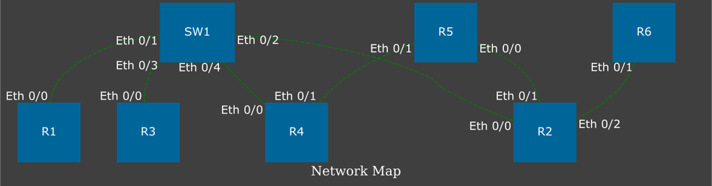

При этом:

- Интерфейсы должны быть записаны с пробелом `Fa 0/0`
- Расположение устройств на схеме может быть другим
- Соединения должны соответствовать схеме
- На схеме не должно быть дублирующихся линков

> Для выполнения этого задания, должен быть установлен graphviz: apt-get install graphviz

> И модуль python для работы с graphviz: pip install graphviz

## Задание 1.4

Создать функцию `write_last_log_to_csv`.

Аргументы функции:

- `source_log` - имя файла в формате csv, из которого читаются данные (пример mail_log.csv)
- `output` - имя файла в формате csv, в который будет записан результат

Функция ничего не возвращает.

Функция `write_last_log_to_csv` обрабатывает csv файл mail_log.csv. В файле mail_log.csv находятся логи изменения имени пользователя. При этом, email пользователь менять не может, только имя.

Функция `write_last_log_to_csv` должна отбирать из файла mail_log.csv только самые свежие записи для каждого пользователя и записывать их в другой csv файл. В файле `output` первой строкой должны быть заголовки столбцов, такие же как в файле `source_log`.

Для части пользователей запись только одна и тогда в итоговый файл надо записать только ее. Для некоторых пользователей есть несколько записей с разными именами. Например пользователь с email c3po@gmail.com несколько раз менял имя:

```
C=3PO,c3po@gmail.com,16/12/2019 17:10
C3PO,c3po@gmail.com,16/12/2019 17:15
C-3PO,c3po@gmail.com,16/12/2019 17:24
```

Из этих трех записей, в итоговый файл должна быть записана только одна - самая свежая:

```
C-3PO,c3po@gmail.com,16/12/2019 17:24
```

Для сравнения дат удобно использовать объекты `datetime` из модуля `datetime`. Чтобы упростить работу с датами, создана функция `convert_str_to_datetime` - она конвертирует строку с датой в формате 11/10/2019 14:05 в объект `datetime`. Полученные объекты `datetime` можно сравнивать между собой. Вторая функция `convert_datetime_to_str` делает обратную операцию - превращает объект `datetime` в строку.

Функции `convert_str_to_datetime` и `convert_datetime_to_str` использовать не обязательно.

```python
import datetime


def convert_str_to_datetime(datetime_str):
    """
    Конвертирует строку с датой в формате 11/10/2019 14:05 в объект datetime.
    """
    return datetime.datetime.strptime(datetime_str, "%d/%m/%Y %H:%M")


def convert_datetime_to_str(datetime_obj):
    """
    Конвертирует строку с датой в формате 11/10/2019 14:05 в объект datetime.
    """
    return datetime.datetime.strftime(datetime_obj, "%d/%m/%Y %H:%M")
```